# Ошибки I и II рода

Автор

Киренская Валерия

## Требования к сдаче и оформлению задания

Заполните этот qmd-файл кодом и ответами. Порядок сдачи задания описан в README.md, на Stepik или Google-class.

1. Старайтесь соблюдать единый стиль оформления и структуру отчёта. Не оставляйте лишние чанки кода, текст или комментарии, которые не относятся к решению задания.
2. Основные результаты представьте на графиках и объясните в тексте. Отдельные таблицы результатов не требуются. Не оставляйте необработанный консольный вывод или отдельные числа без пояснений.
3. Графики должны быть достаточно крупными, с читаемыми русскими подписями, содержательным заголовком и правильно названными осями. Не используйте фон ggplot2 по умолчанию.
4. Ответы на вопросы и интерпретации результатов, включая графики, пишите обычным текстом, а не комментариями к коду. Код и его вывод не заменяют ответ на вопрос.
5. Сохраняйте исходную структуру проекта в репозитории. Не добавляйте лишние файлы, которые не относятся к проекту или выполнению заданий.
6. Оформление коммитов и веток на GitHub должно соответствовать общим правилам для всех курсов Института биоинформатики.

## О задании

На занятии мы оценивали ошибки I и II рода. Теперь с помощью симуляций вы **графически исследуете**, как вероятности этих ошибок у двухвыборочного t-теста зависят от уровня значимости, объёма выборки и распределения данных.

Для этого вы проведёте серии симуляций для разных **сочетаний параметров**.

**Результат выполнения домашнего задания: шесть графиков зависимости ошибки I или II рода от $\alpha$ и их интерпретация, выводы.**

## Условия

> Если условия не будут понятны с первого раза, то посмотрите на таблицу в разделе **“Сочетания условий”**.
1. Для сравнения средних двух независимых групп используйте `t.test()`.
2. Объём выборки в каждой из двух групп ($X$ и $Y$) должен быть одинаковым: **$n$ = 3, 10, 30, 100**. Здесь $n$ – объём **одной** выборки. В одном повторении сравниваются две выборки, то есть всего $2n$ наблюдений.
3. Исследуйте **нормальное, равномерное и экспоненциальное распределения**.
4. Проверяйте гипотезы $H_0: \mu_X = \mu_Y$ и $H_a: \mu_X \ne \mu_Y$. Для каждого типа распределения и объёма выборки рассмотрите два сценария:
- **$H_0$ верна:** генерируйте две независимые выборки из распределения с одинаковыми параметрами для обеих групп. Средние генеральных совокупностей равны.
- **$H_0$ неверна:** генерируйте две независимые выборки из распределений выбранного типа, выбрав параметры так, чтобы средние генеральных совокупностей различались.

> **Параметры распределений выберите один раз для каждого типа распределения и сценария.** В отчёте укажите выбранные параметры, истинные средние и истинные стандартные отклонения обеих групп. Затем сохраняйте параметры при изменении $n$ и $\alpha$.

> Рекомендуем для разных типов распределений задать одинаковое истинное среднее группы $X$ и одинаковое истинное среднее группы $Y$ в соответствующем сценарии.
5. Используйте уровни значимости **$\alpha = 0.01, 0.02, \ldots, 0.20$ с шагом 0.01**.
6. Для каждого сочетания типа распределения, объёма выборки и сценария проведите одну серию из **1000 повторений**. Вероятность ошибки оценивайте по её частоте в серии.

### Сочетания условий

**Переберите все сочетания:** 2 сценария × 3 типа распределений × 4 объёма выборки × 20 уровней значимости. В ячейках указан диапазон $\alpha$.

| Сценарий | Тип распределения | $n = 3$ | $n = 10$ | $n = 30$ | $n = 100$ |
| --- | --- | --- | --- | --- | --- |
| **$H_0$ верна** | Нормальное | $[0.01, 0.20]$ | $[0.01, 0.20]$ | $[0.01, 0.20]$ | $[0.01, 0.20]$ |
|  | Равномерное | $[0.01, 0.20]$ | $[0.01, 0.20]$ | $[0.01, 0.20]$ | $[0.01, 0.20]$ |
|  | Экспоненциальное | $[0.01, 0.20]$ | $[0.01, 0.20]$ | $[0.01, 0.20]$ | $[0.01, 0.20]$ |
| **$H_0$ неверна** | Нормальное | $[0.01, 0.20]$ | $[0.01, 0.20]$ | $[0.01, 0.20]$ | $[0.01, 0.20]$ |
|  | Равномерное | $[0.01, 0.20]$ | $[0.01, 0.20]$ | $[0.01, 0.20]$ | $[0.01, 0.20]$ |
|  | Экспоненциальное | $[0.01, 0.20]$ | $[0.01, 0.20]$ | $[0.01, 0.20]$ | $[0.01, 0.20]$ |

Каждая ячейка с диапазоном $\alpha$ соответствует одной серии из **1000 повторений** для указанного сценария, типа распределения и объёма выборки. **Один и тот же набор p-значений этой серии используйте для всех 20 уровней $\alpha$: новые выборки для каждого $\alpha$ генерировать не нужно.**

Всего получится **24 серии**. Для каждой серии оцените вероятность ошибки I или II рода (в зависимости от сценария) при всех **20 уровнях $\alpha$**. В результате получите по **240 оценок для каждого типа ошибки (сценария)**.

## Проведение симуляции

1. **Задайте seed один раз перед симуляциями**.
2. В каждом повторении генерируйте две новые независимые выборки, применяйте t-тест и сохраняйте p-значение.
3. Проведите симуляции и сохраните оценки вероятностей ошибок I или II рода для каждого сочетания типа распределения, объёма выборки, сценария и уровня значимости.

```r
set.seed(42)
```

```r
library(tidyverse)
library(ggplot2)
```

Условия, которые я выбрала для симуляции

| Распределение | Группа X | Группа Y, H₀ верна | Группа Y, H₀ неверна |
| --- | --- | --- | --- |
| Нормальное | N(5; 1): среднее 5, sd 1 | N(5; 1) | N(10; 1): среднее 10, sd 1 |
| Равномерное | U(0; 10): среднее 5, sd 2.89 | U(0; 10) | U(0; 20): среднее 10, sd 5.77 |
| Экспоненциальное | Exp(0.2): среднее 5, sd 5 | Exp(0.2) | Exp(0.1): среднее 10, sd 10 |

```r
n <- c(3, 10, 30, 100)
alphas <- seq(0.01, 0.20, 0.01)
repeats <- 1000

#Генератор выборки с нормальным распределением
generate_norm <- function (n, sample_mean, sample_sd) {
  samples <- rnorm(n = n, mean = sample_mean, sd = sample_sd)
  return(samples)
}

#Генератор выборки с экспоненциальным распределением
generate_exp <- function (n, sample_rate) {
  samples <- rexp(n = n, rate = sample_rate)
  return(samples)
}

#Генератор выборки с равномерным распределением
generate_uni <- function (n, a, b) {
  samples <- runif(n = n, min = a, max = b)
  return(samples)
}

#На основе генераторов рассчитывает p.value
simulate_pvalue <- function (n, generator_x, generator_y, repeats = 1000) {
  p.values <- replicate(n = repeats, t.test(generator_x(n), generator_y(n))$p.value
    )
  return(p.values)
}
```

Нормальное распределение

```r
# Ошибка 1 рода
error_freq_I_norm <- data.frame(alpha = alphas)

for (i in n){
  p.value <- simulate_pvalue(i, function(k) generate_norm(k, 5, 1),
                                function (k) generate_norm(k, 5, 1))
  errors <- c()
  for (a in alphas){
    err_freq <- sum(p.value < a) / repeats
    errors <- append(errors, err_freq)
  }
  error_freq_I_norm[[as.character(i)]] <- errors
}

# Ошибка 2 рода
error_freq_II_norm <- data.frame(alpha = alphas)

for (i in n){
  p.value <- simulate_pvalue(i, function(k) generate_norm(k, 5, 1),
                                function (k) generate_norm(k, 10, 1))
  errors <- c()
  for (a in alphas){
    err_freq <- sum(p.value >= a) / repeats
    errors <- append(errors, err_freq)
  }
  error_freq_II_norm[[as.character(i)]] <- errors
}
```

Экспоненциальное распределение

```r
#Ошибка 1 рода
error_freq_I_exp <- data.frame(alpha = alphas)

for (i in n){
  p.value <- simulate_pvalue(n = i, function(k) generate_exp(k, 0.2), function (k) generate_exp(k, 0.2))
  errors <- c()
  for (a in alphas){
    err_freq <- sum(p.value < a) / repeats
    errors <- append(errors, err_freq)
  }
  error_freq_I_exp[[as.character(i)]] <- errors
}

# Ошибка 2 рода
error_freq_II_exp <- data.frame(alpha = alphas)

for (i in n){
  p.value <- simulate_pvalue(n = i, function(k) generate_exp(k, 0.2), function (k) generate_exp(k, 0.1))
  errors <- c()
  for (a in alphas){
    err_freq <- sum(p.value >= a) / repeats
    errors <- append(errors, err_freq)
  }
  error_freq_II_exp[[as.character(i)]] <- errors
}
```

Равномерное распределение

```r
#Ошибка 1 рода

error_freq_I_uni <- data.frame(alpha = alphas)

for (i in n){
  p.value <- simulate_pvalue(n = i, function(k) generate_uni(k, 0, 10), function (k) generate_uni(k, 0, 10))
  errors <- c()
  for (a in alphas){
    err_freq <- sum(p.value < a) / repeats
    errors <- append(errors, err_freq)
  }
  error_freq_I_uni[[as.character(i)]] <- errors
}

# Ошибка 2 рода
error_freq_II_uni <- data.frame(alpha = alphas)

for (i in n){
  p.value <- simulate_pvalue(n = i, function(k) generate_uni(k, 0, 10), function (k) generate_uni(k, 0, 20))
  errors <- c()
  for (a in alphas){
    err_freq <- sum(p.value >= a) / repeats
    errors <- append(errors, err_freq)
  }
  error_freq_II_uni[[as.character(i)]] <- errors
}
```

## Постройте графики

1. Постройте шесть графиков: **три распределения × два типа ошибок**. Допустимы шесть отдельных рисунков или один общий рисунок из шести панелей.
2. На каждом графике по оси **X** отложите $\alpha$, по оси **Y** – вероятность ошибки I или II рода. Покажите **четыре кривые**, соответствующие объёмам выборки $n = 3, 10, 30, 100$.
3. Используйте одинаковые цвета для одинаковых $n$ и одинаковые границы осей для одного типа ошибки.

> На графиках для ошибки I рода добавьте пунктирную линию **$y = \alpha$** для сравнения с заданным уровнем значимости.

```r
transform_to_long <- function(data) {
  long <- data |>
    pivot_longer(cols = -alpha, names_to = "n", values_to = "error_frequency") |>
    mutate(n = factor(n, levels = c("3", "10", "30", "100")))
  return(long)
}

plot_error <- function(data, title, type) {
  long_data <- transform_to_long(data)
  p <- ggplot(data = long_data, aes(x = alpha, y = error_frequency, color = n)) +
    geom_line() +
    geom_point() +
    labs(
      title = title,
      x = "Уровень значимости α",
      y = paste("Вероятность ошибки", type, "рода"),
      color = "Объем выборки"
    ) +
  theme_bw()

  if (type == "I") {
    p <- p + geom_abline(intercept = 0, slope = 1, linetype = "dashed", linewidth = 1) +
      scale_y_continuous(limits = c(0, 0.3))
  } else {
    p <- p + scale_y_continuous(limits = c(0, 1))
  }
  p
}
```

Нормальное распределение

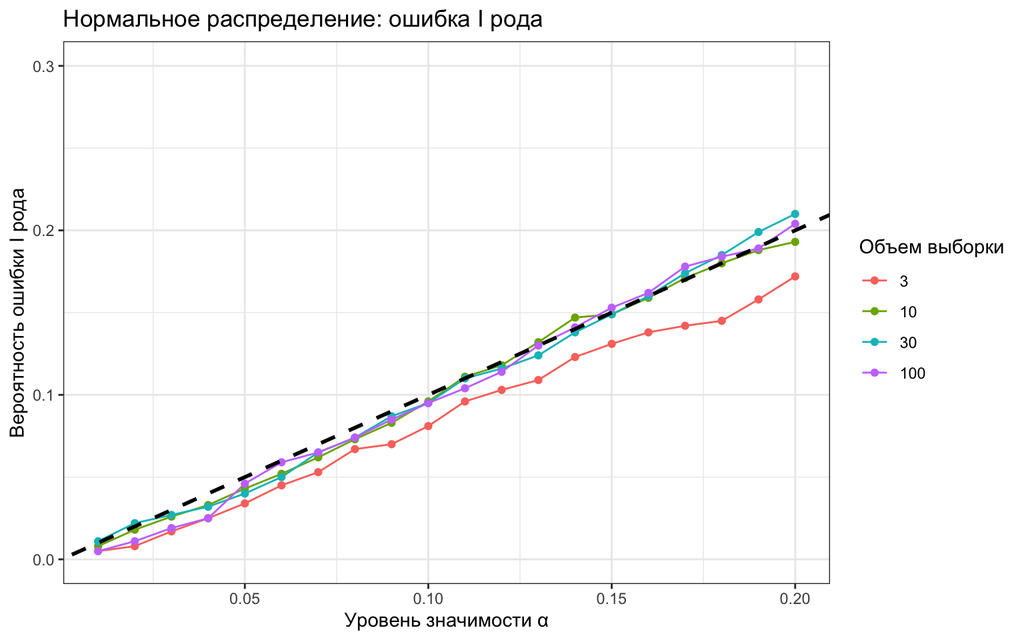

```r
plot_error(data = error_freq_I_norm, title = "Нормальное распределение: ошибка I рода", type = "I")
```

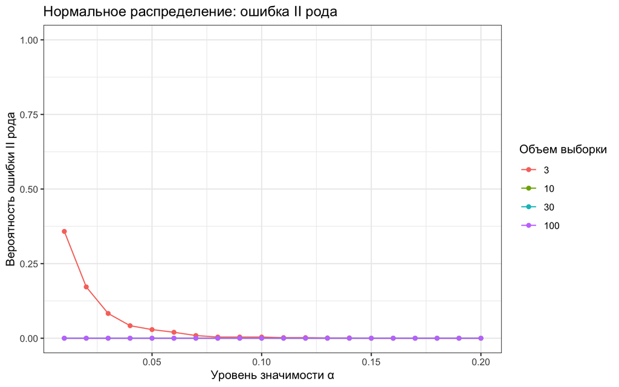

```r
plot_error(data = error_freq_II_norm, title = "Нормальное распределение: ошибка II рода", type = "II" )
```

Экспоненциальное распределение

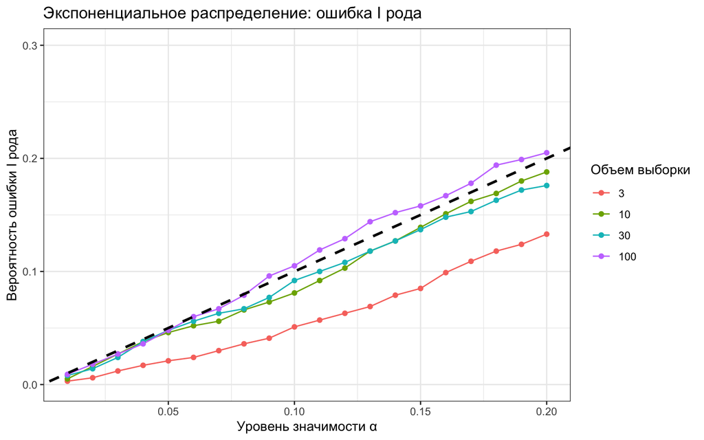

```r
plot_error(data = error_freq_I_exp, title = "Экспоненциальное распределение: ошибка I рода", type = "I")
```

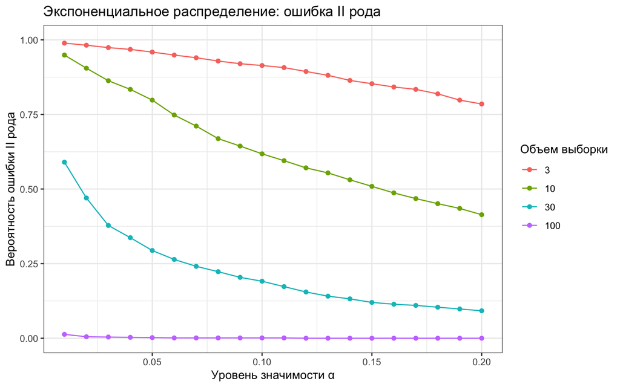

```r
plot_error(data = error_freq_II_exp, title = "Экспоненциальное распределение: ошибка II рода", type = "II" )
```

Равномерное распределение

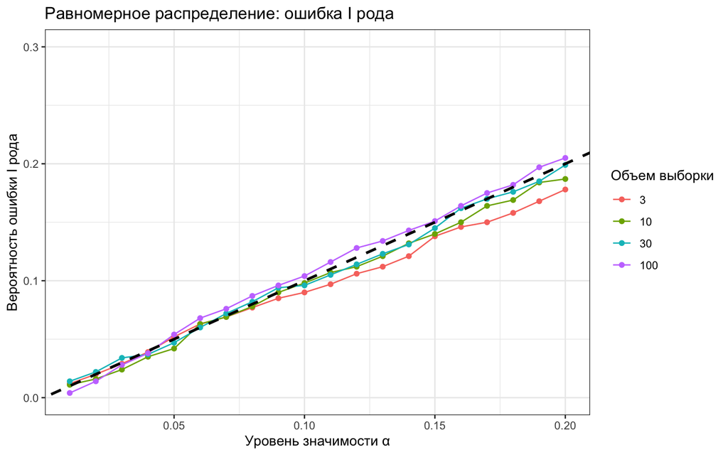

```r
plot_error(data = error_freq_I_uni, title = "Равномерное распределение: ошибка I рода", type = "I")
```

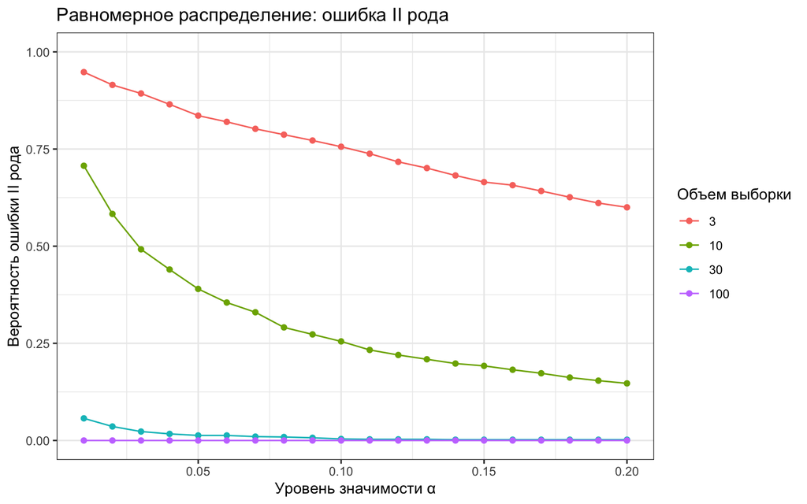

```r
plot_error(data = error_freq_II_uni, title = "Равномерное распределение: ошибка II рода", type = "II" )
```

## Выводы

Напишите выводы, попутно ответив на вопросы:

1. Насколько оценённая вероятность ошибки I рода близка к $\alpha$ в каждом случае? Видны ли отклонения для каких-либо распределений и объёмов выборки? Если видны, в какую сторону?

Ответ: У нормального и равномерного распределения линии частот ошибок идут вдоль линии ожидаемых частот, однако при размере выборки n = 3 у нормального распределения есть небольшие отклонения в меньшую сторону от ожидаемых частот. У экспоненциального распределения более интересная картина. Для значений n = 10, 30, 100 кривые идут вдоль кривой с теоретическими частотами (пунктир), а при n = 3 линия ниже пунктирной линии (в среднем на 0.05). Такое поведение может быть обусловлено характером распределения и маленьким размером выборки. В экспоненциальном распределении выбросы встречаются редко, а основная масса значений - маленькие, ложноположительные результаты могут быть получены при аномально больших значениях разности средних, но при маленьком размере выборки выбросы увеличивают стандартное отклонение, получается, что с ростом стандартного отклонения при маленьком размере выборки - t статистика чаще будет принимать маленькие значения, что уменьшает вероятность ошибок I рода.

2. Как меняется вероятность ошибки II рода при изменении $\alpha$ и $n$? Как вы думаете, почему? Ответ: Начнем с общего для всех трех распределений. При n = 100 частота ошибок II рода близка к 0, вероятнее всего это обусловлено увеличением мощности критерия. При увеличении выборки сужается доверительный интервал и уменьшается стандартная ошибка оценки разности средних, это приводит к редким случаям покрытия 0 доверительным интервалом -> снижается частота ошибок II рода. Статистика t критерия тоже будет расти, так как она прямо пропорциональна $\sqrt{n}$ и увеличивается с уменьшением стандартной ошибки.

Для всех распределений вероятность ошибки II рода уменьшается с ростом alpha. Это ожидаемо, так как alpha задает порог для p-value, чем больше alpha, тем больше значений будут меньше p-value -> H0 отвергается чаще, но это также ведет к увеличению ошибок I рода. В реальности нельзя просто увеличить значение alpha, так как у нас будет падать уровень доверия, а тест будет ошибаться чаще.

У нормального распределения ошибка II рода близка к нулю уже при n = 10 (частота ошибок заметна лишь при n = 3 и alpha < 0.05). Хуже всего картина у экспоненциального распределения, частота ошибок II рода близка к 0 лишь при n = 100, при других значениях n частота ошибок с ростом alpha снижается медленно. Так, при n = 3 линия лежит в диапазоне от 0.8 до 1, что говорит о том, что от 80% до 100% сравнений не находят статистически значимых различий между средними в группах. У равномерного при уже при n = 10 ситуация намного лучше, чем в экспоненциальом распределении, частоты ошибок снижаются быстро с ростом alpha. При n = 30 линия уже близка к значению 0.

Стоит отметить, что при одинаковой разнице средних = 5 у распределений разный разброс: 1 у нормального, 2.9 и 5.8 у равномерного и 5 и 10 у экспоненциального. Рост стандартного отклонения приводит к росту стандартной ошибки -> рост ДИ -> больше вероятность захватить 0.

3. Чем различаются результаты для трёх распределений?

Ответ: У нормального распределения ошибка I рода близка к alpha, а ошибка II рода близка к нулю уже при n = 10. У равномерного распределения ошибка II рода убывает медленнее, а у экспонициального распределения ошибка I рода при малых n ниже alpha, в то время как ошибка II рода остается высокой до n = 100. Эти различия могут объяснятся формой и разбросом распределений, значения в экспоненциальном распределении сдвинуты влево, а стандартное отклонение имеет самое большое значение при той же разнице средних, по этой причине различия труднее обнаружить, но с ростом n ситуация становится лучше.

## Дополнительное задание

Выберите один тип распределения и объём выборки $n=10$. Для каждого из двух сценариев возьмите параметры из основного задания и рассмотрите ещё два варианта, изменяя один выбранный параметр распределения. Укажите, какой параметр и в какой группе или группах вы изменяете.

Остальные параметры распределения, объём выборки, уровни $\alpha$ и число повторений оставьте прежними.

**Постройте два графика**: для ошибки I рода и для ошибки II рода. На каждом покажите три кривые – исходный вариант (из основного задания) и два изменённых.

```r
#Ошибка I рода

diff_sd <- c(1, 3, 7)
error_I_diff_sd <- data.frame(alpha = alphas)
for(i in diff_sd){
  p.value <- simulate_pvalue(n = 10, function (k) generate_norm(k, 5, i), function (k) generate_norm(k, 5, i))
  errors <- c()
  for (a in alphas){
    error <- sum(p.value < a) / repeats
    errors <- append(errors, error)
  }
  error_I_diff_sd[[as.character(i)]] <- errors
}

#Ошибка II рода

diff_sd <- c(1, 3, 7)
error_II_diff_sd <- data.frame(alpha = alphas)
for(i in diff_sd){
  p.value <- simulate_pvalue(n = 10, function (k) generate_norm(k, 5, i), function (k) generate_norm(k, 10, i))
  errors <- c()
  for (a in alphas){
    error <- sum(p.value >= a) / repeats
    errors <- append(errors, error)
  }
  error_II_diff_sd[[as.character(i)]] <- errors
}
```

```r
transform_to_long_add <- function(data) {
  long <- data |>
    pivot_longer(cols = -alpha, names_to = "sd", values_to = "error_frequency") |>
    mutate(sd = factor(sd, levels = c("1", "3", "7")))
  return(long)
}

plot_error_add <- function(data, title, type) {
  long_data <- transform_to_long_add(data)
  p <- ggplot(data = long_data, aes(x = alpha, y = error_frequency, color = sd)) +
    geom_line() +
    geom_point() +
    labs(
      title = title,
      x = "Уровень значимости α",
      y = paste("Вероятность ошибки", type, "рода"),
      color = "Стандартное отклонение"
    ) +
  theme_bw()

  if (type == "I") {
    p <- p + geom_abline(intercept = 0, slope = 1, linetype = "dashed", linewidth = 1) +
      scale_y_continuous(limits = c(0, 0.3))
  } else {
    p <- p + scale_y_continuous(limits = c(0, 1))
  }
  p
}
```

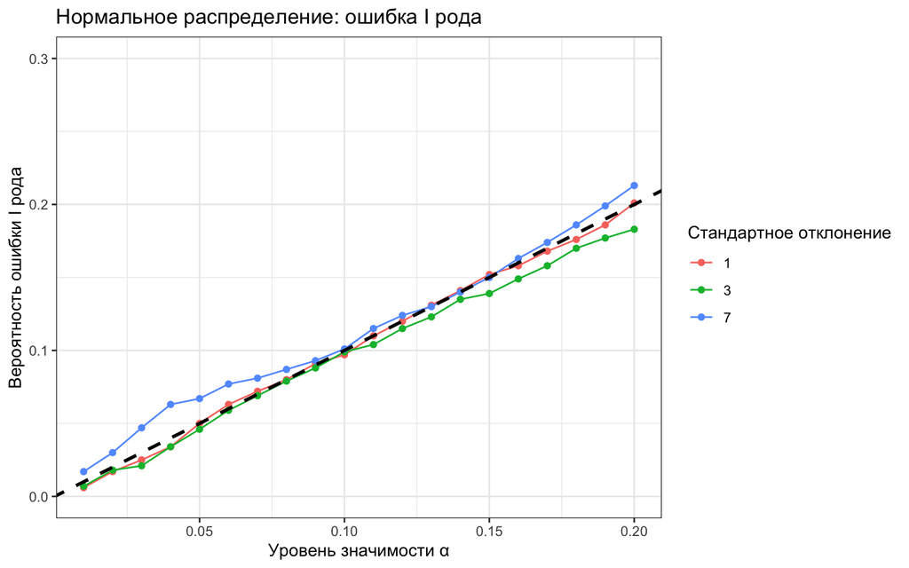

```r
plot_error_add(data = error_I_diff_sd, title = "Нормальное распределение: ошибка I рода", type = "I")
```

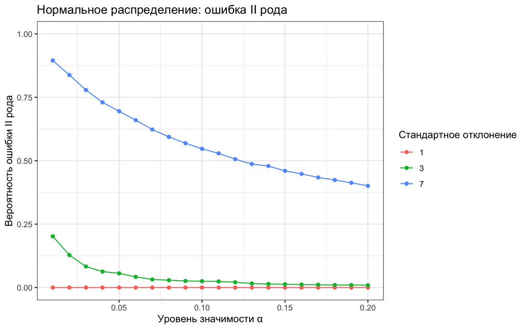

```r
plot_error_add(data = error_II_diff_sd, title = "Нормальное распределение: ошибка II рода", type = "II" )
```

Какие изменения вы наблюдаете? Почему?

Ответ: В данном задании я выбрала нормальное распределение. В качестве изменяемого параметра я выбрала стандартное отклонение сразу в обеих группах: 1, 3, 7. Остальные параметры (средние 5 и 10, n = 10, alpha, число повторений) остались прежними. Ошибка I рода от sd практически не зависит: линии идут вдоль пунктира, небольшие отклонения (например, при sd = 7 при малых alpha) скорее всего случайны (так как оценка частоты ошибок тоже случайная величина), так как при верной H0 распределение t статистики не зависит от sd (числитель статистики критерия равен 0). Ошибка II рода сильно зависит от sd. При sd = 1 она равна 0 при всех alpha, при sd = 3 заметна лишь при малых alpha (около 0.2 при alpha = 0.01), а при sd = 7 максимальна (от 0.4 до 0.9). Я думаю, что это связано с тем, что с ростом sd растёт стандартная ошибка оценки разности средних, что ведёт к увеличению ДИ и частоты покрытия значения 0. Это все ведет к уменьшению мощности критерия.